# Bahia Lomas Red Knot report, tables and figures

# Bahia Lomas receiver station habitat, activity, and detection summary

The receiving station at Buque Quemado never functioned correctly (and thus never detected a single individual) and is excluded from further consideration. All remaining stations comprised three active antennas. Thus, in site-level summaries, we do not attempt to adjust detection numbers or times based on the number of active antennas.

**Stu, please confirm the orientation of antennas before I summarize habitat in these assumed primary detection zones for birds on the ground.** Given current bearings (true north), a few antennas seem aligned primarily over upland (NW @ E. Pepita, NW @ E. Miramar, ENE @ E. El Plantano).

[interactive chart not shown]

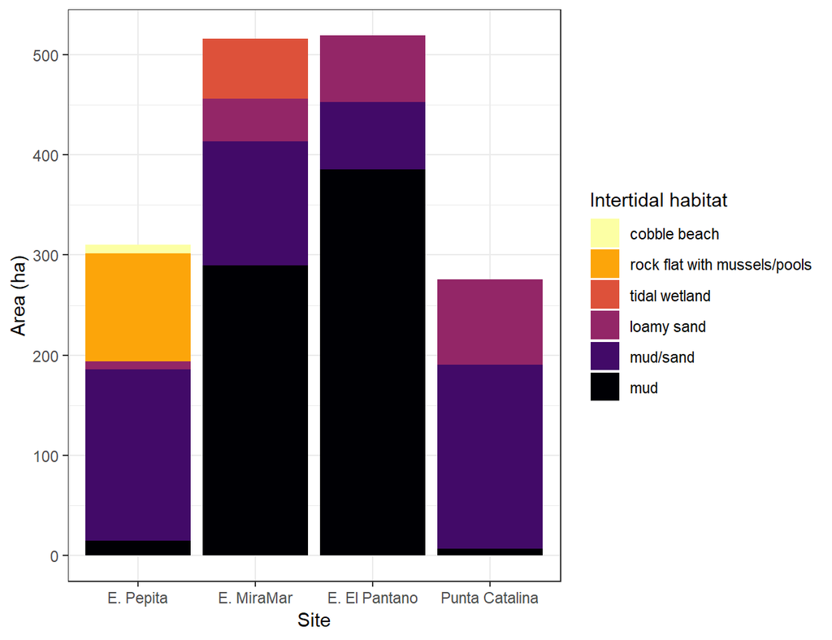

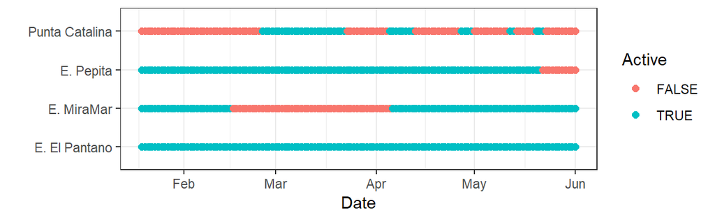

## Number of individuals detected daily across all stations

Total number of individual Hudsonian Godwits (HUGO) and Red Knots (REKN) detected daily by Bahia Lomas receiving stations. Receiver station activity is indicated along the top of the figure.

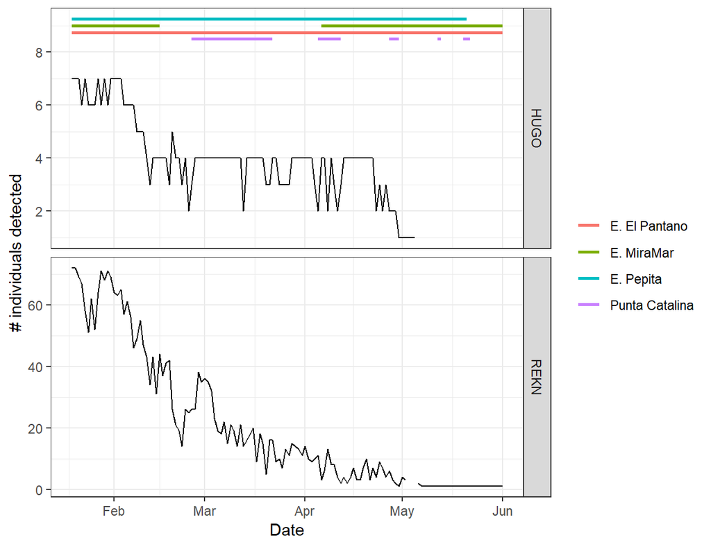

# Site-level summary plots

## Weekly total time of detection

Here, for each week, we sum the total time of detection of all individual Hudsonian Godwits (HUGO) and Red Knots (REKN) by receiving station. The corresponding period of activity for each receiving station is indicated along the top of the figure. E. Pepita is the primary site of detection, perhaps not surprisingly given its close proximity to the trapping location. E. MiraMar also detected birds regularly while it was functional. E. El Pantano and Punta Catalina were used much more sparingly, as better illustrated in the next figure.

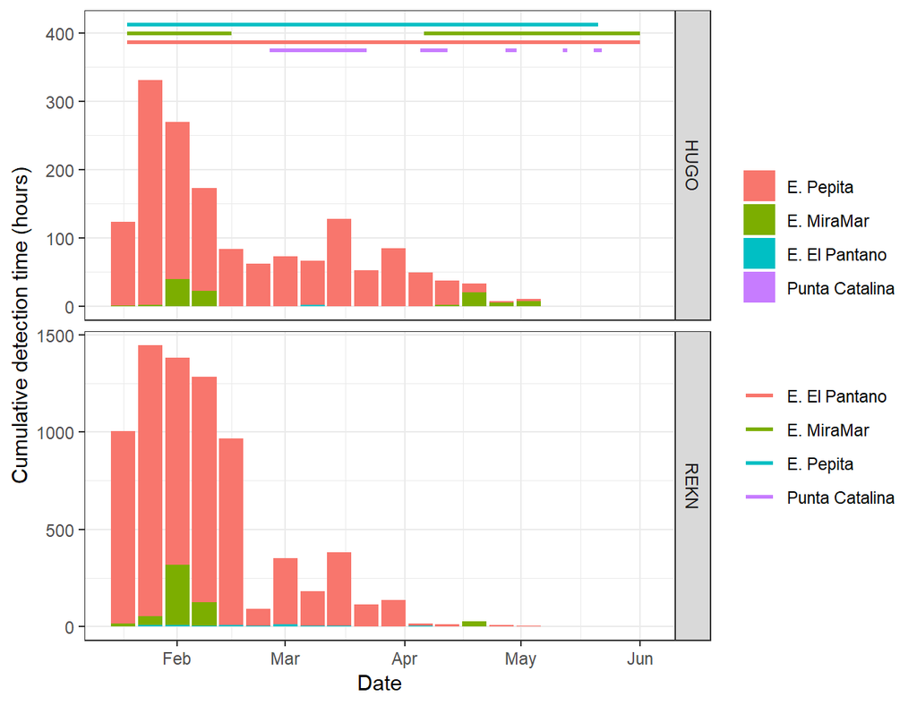

## Daily total time of detection

Here, for each day, we sum the total time of detection of all individual Hudsonian Godwits (HUGO) and Red Knots (REKN) by receiving station. The corresponding period of activity for each receiving station is indicated in grey. Again, it is clear that E. Pepita is the primary site of detection, with E. MiraMar also detecting birds regularly while it was functional. E. El Pantano was visited consistently but for shorter durations and by fewer individuals (see also next figure). Punta Catalina was used much more briefly and sporadically, and by many fewer individuals, as better illustrated in the next figure.

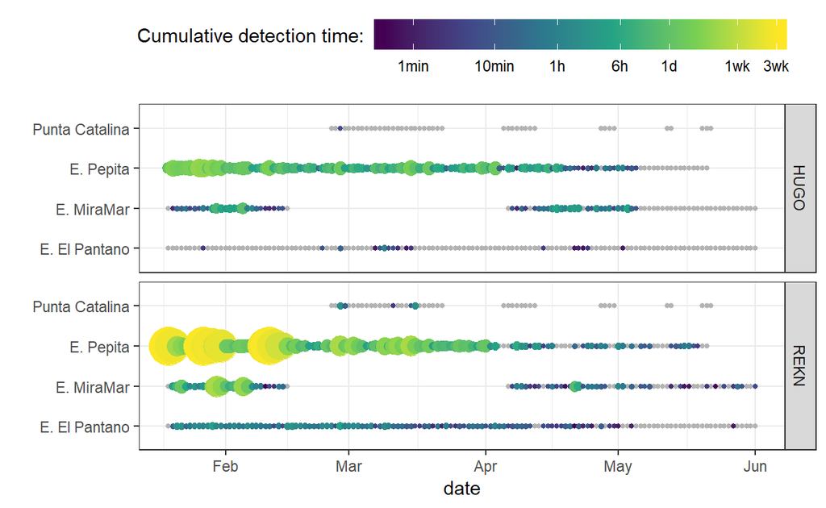

## Daily number of individuals detected

Here, for each day, we indicate the total number of individual Hudsonian Godwits (HUGO) and Red Knots (REKN) detected by receiving station. The corresponding period of activity for each receiving station is indicated in grey. Again, it is clear that E. Pepita is the primary site of detection, with E. MiraMar also regularly detecting most birds present while it was functional. E. El Pantano was visited consistently by Red Knots, although by fewer individuals that E. Pepita and E. MiraMar. Punta Catalina was visited by only a few individuals on a few occasions in late February and early March.

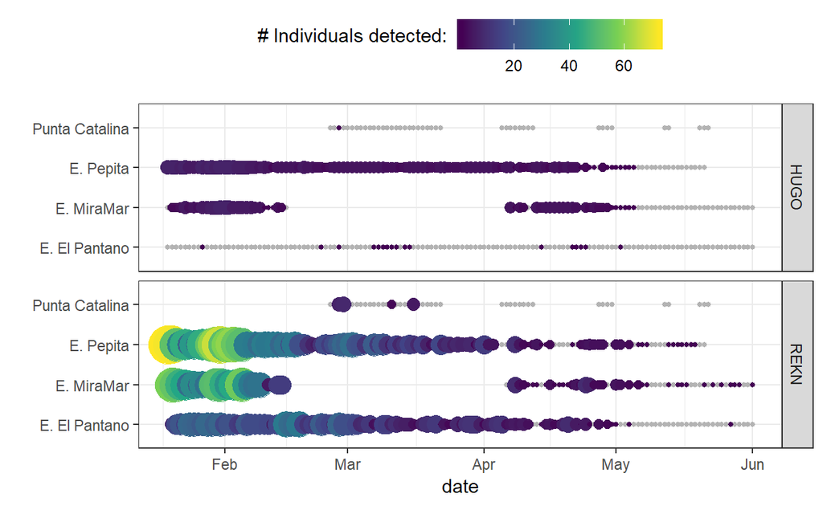

Same information as above, illustrated with line graphs rather than point size/color.

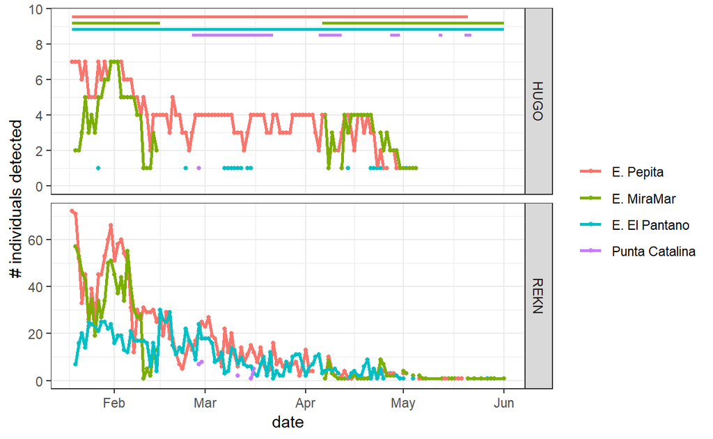

## Last detection by Bahia Lomas station (weekly)

Weekly number of Hudsonian Godwits (HUGO) and Red Knots (REKN) last detected by Bahia Lomas receiving stations. Lines across the top of the HUGO plot illustrate the period that each station was actively listening for tagged birds. Which receivers last detected Red Knots? Solid vertical line is the median date of last detection; dashed vertical lines indicate the 10<sup>th</sup> and 90<sup>th</sup> percentiles of last detection (pretty meaningless for HUGO). The site nearest the capture location, E. Pepita, most commonly was the last station of detection for Red Knots, followed by E. El Pantano and E. MiraMar, though their relative importance is somewhat complicated by the fact that E. Miramar was inactive from mid-February through early April and Punta Catalina functioned consistently only through mid/late-March and sporadically thereafter. With that said, the area around Punta Catalina seemed to be used very infrequently by tagged birds relative to E. Pepita in particular, but also E. El Pantano and E. MiraMar when all stations were active (refer to above figures).

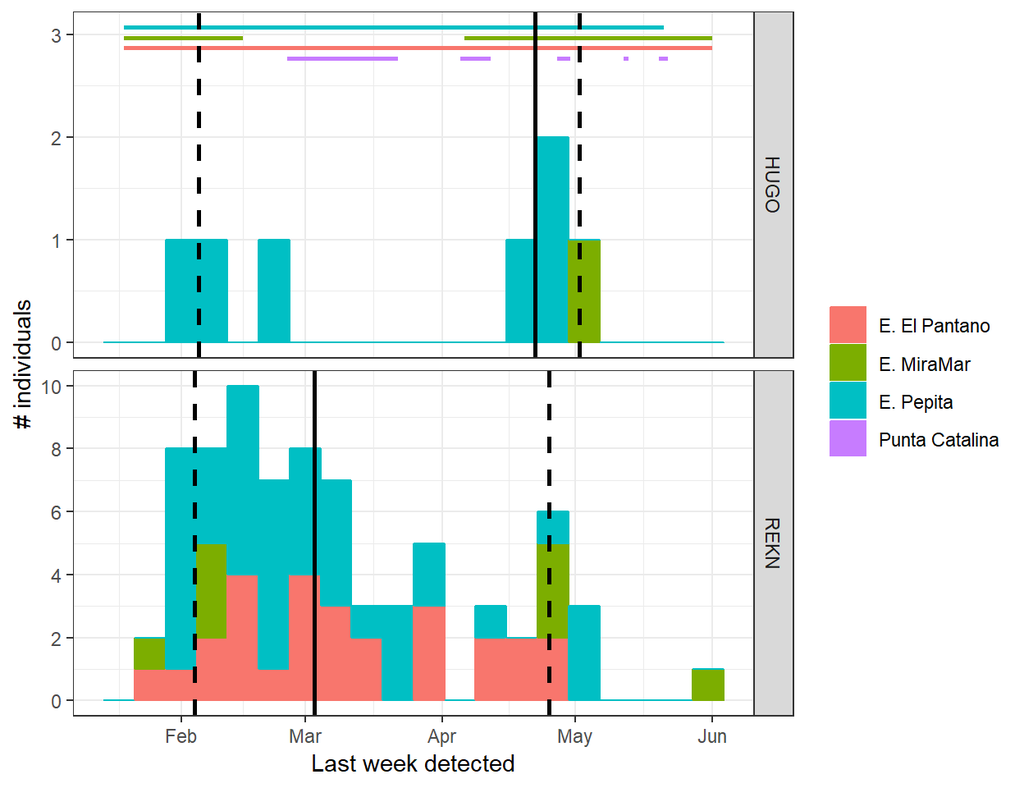

## Relative Red Knot detections within and among stations

This distinguishes Red Knot detections by receiving station antenna, showing the apparent relative site use within a station’s detection zones as well as among stations. Points are located along the approximate antenna detection axis at a distance of 3 km from the receiving station. This again illustrates that most detections occurred near and northwest of the capture location (red crosshair) at E. Pepita, with considerably shorter total detection duration, and numbers of individuals detected, as one moves east along the southern shore of Bahia Lomas towards Punta Catalina. Note however that the relative use of E. MiraMar is likely considerably underestimated due to station failure from mid-February to early April. See the next figure for a more equitable comparison of the relative use of the three primary detection sites (E. Pepita, E. MiraMar, and E. El Platano). It is important to note that cumulative detection time is also a function of detectability, which is likely to be higher when birds are near the receiving station or flying. Thus, cumulative detection time is likely not strictly an index of site use or importance.

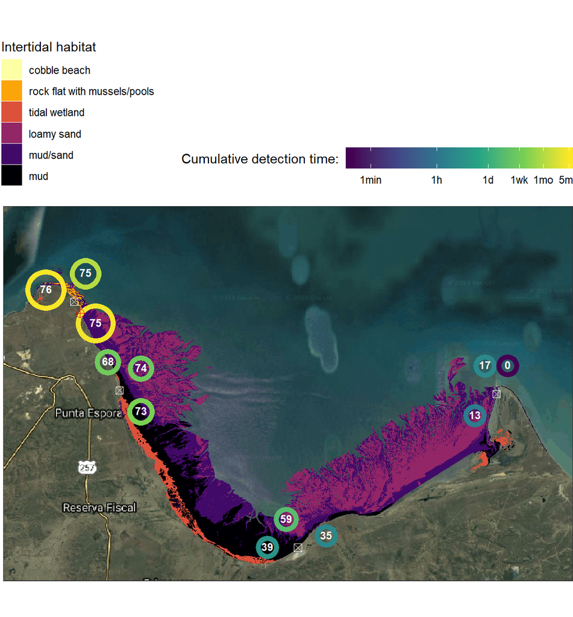

## Relative Red Knot detections within and among stations (peak activity)

Here we focus on the relative use of the three primary detection sites (E. Pepita, E. MiraMar, and E. El Platano) during a period (capture to mid-February) when most individual Red Knots (REKN) were present on the landscape and all three stations were fully functional. Points are located along the approximate antenna detection axis at a distance of 3 km from the receiving station. This again illustrates that the vast majority of detection time occurred near and northwest of the capture location (red crosshair) at E. Pepita, with considerably shorter total detection duration, and numbers of individuals detected, as one moves east along the southern shore of Bahia Lomas towards Punta Catalina. It is important to note that cumulative detection time is also a function of detectability, which is likely to be higher when birds are near the receiving station or flying. Thus, cumulative detection time is likely not strictly an index of site use or importance.

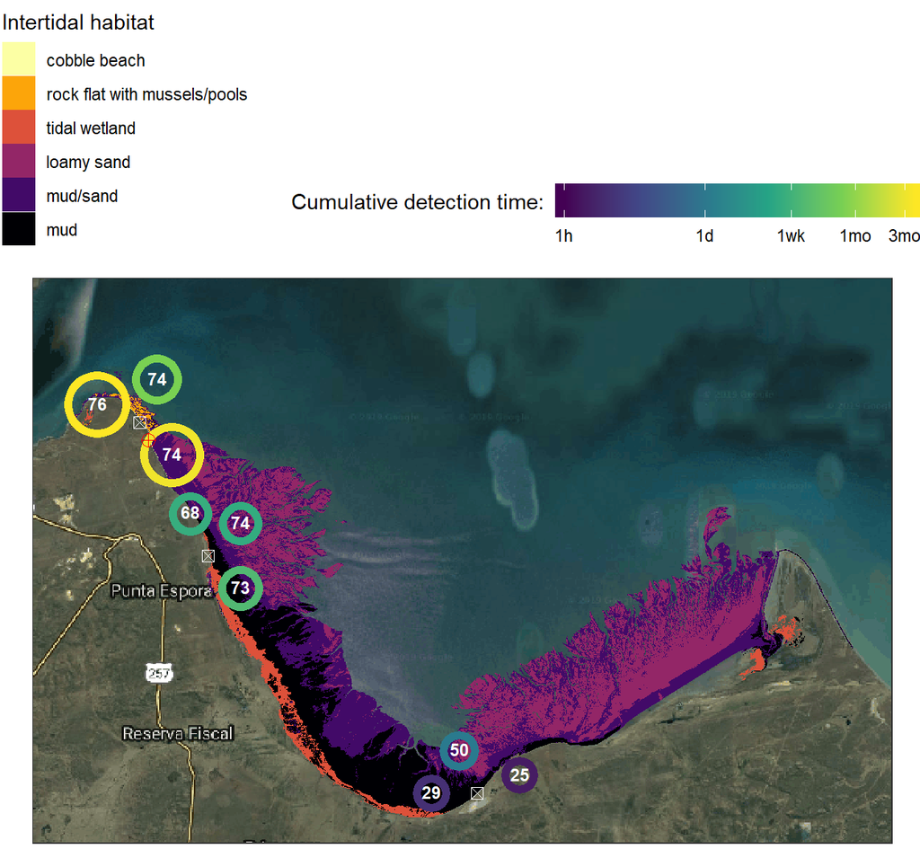

## Receiving station detections and association with tides

Here we compare the proportional distribution of tide heights while each receiving station was active (grey background bars) with tide heights during Red Knot (REKN) detections. Detections at E. Pepita and E. El Pantano occur generally across the distribution of tide heights at those sites, with a slightly disproportionate increase in detection rate at some higher water levels (although not extreme high water at E. Pepita). In contrast, REKN are strongly disproportionately detected at E. MiraMar and Punta Catalina during very high tides, suggesting that knots are using these sites preferentially, or that they are restricted to more detectable areas, during very high water. These patterns are fairly consistent across different detection zones around each site; that is, the patterns apply generally around a station.

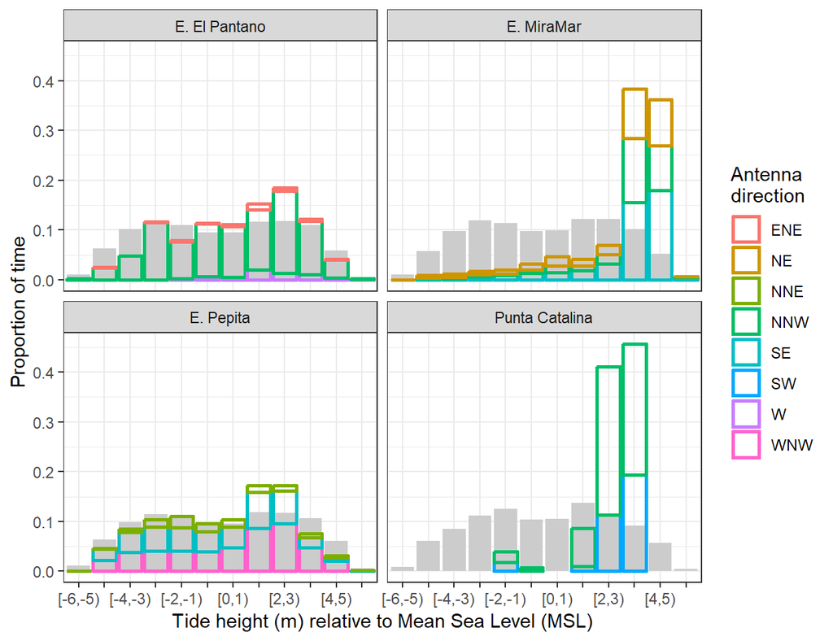

## Habitat “use” with tide as determined by relative detection time on different antennas

Here we examine how tide may be associated with differential use of habitats using the relative detection time of Red Knots (REKN) on different antennas. Each antenna detects birds in a limited space, and that space can be approximated and associated with habitat. We constrain the “detection zone” of each antenna to an ellipse 2 km in length starting at the receiving station. The major axis of the ellipse aligns with the orientation of the antenna. For the minor axis of the ellipse we use a distance of 1.6 km at a distance of 1 km from the receiving station to approximate the detection width of the antenna based on the manufacturer’s specifications (see interactive figure at top of this document to visualize these “primary detection zones for REKN on the ground.” While only a subjective approximation, we think this best reflects the detection zone of each antenna for a REKN on the ground. REKN detected while flying may be detected at much greater ranges, but we have no way to identify flying REKN versus REKN on the ground. Whether it represents selection for habitats or simply a use of habitat available, REKN detections at antennas with a higher proportion of mud occurred at the highest predicted tides. Based on the habitat map above, it appears that “mud” habitats are likely among the last to flood with high tides.

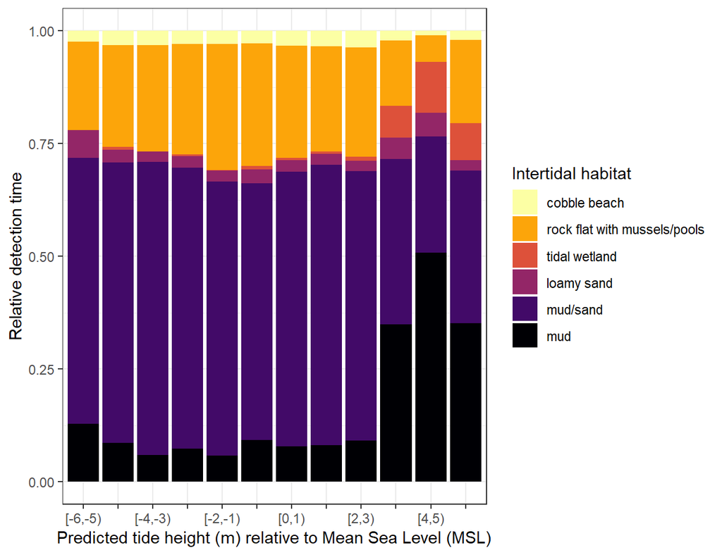